# Chapter 6 Lab 4 - Hierarchical Clustering

# Goal

In this lab, you will learn how to apply and use `Hierarchical Clustering (HC)` on a game dataset.

There are many different R imlementations of `HC`; we are going to use the following functions:

- `hclust` from the built-in `stats` package (url: https://stat.ethz.ch/R-manual/R-devel/library/stats/html/00Index.html)
- `agnes` and `diana` from the `cluster` package (url: https://cran.r-project.org/web/packages/cluster/cluster.pdf)

Among these functions, `hclust` and `agnes` are agglomerative HC, and `diana` is divisive HC. For more about what agglomerative and divisive algorithms are, please review the Chapter.

## Brief refresher

Unlike partitional methods, Hierarchical Clustering does not produce a single clustering result. Its output takes the form of a tree structure called *dendrogram* that represents how the data can be grouped based on their similarity. Users can select a within-cluster similarity value to cut the tree, which results in one specific clustering result. Therefore, there can be many clustering results one can deduce from one resultant tree.

## Preparation

We first load the following packages (install if you need to).

```r
library(caret) # for feature scaling
options(repos = c(CRAN = "http://cran.rstudio.com"))
install.packages("tidyverse", dependencies = TRUE)
library(tidyverse)  # data manipulation
library(cluster)    # clustering algorithms
library(factoextra) # clustering visualization
```

```r
library(dendextend) # for comparing two dendrograms
```

# Step 1: Load the data set

Load data and convert to appropriate data type. We will be using Dotalicious data here like in the previous labs, so make sure the directory structure is where you put the file, we assume the file is in the local directory. These steps are similar to previous labs.

```r
# data
Dota_Data <- read.csv("DoTalicious_cleaned1000players.csv", fileEncoding="UTF-8-BOM")
summary(Dota_Data)
```

```
##     PlayerID       GamesPlayed         GamesWon         GamesLeft
##  Min.   :   0.0   Min.   :   0.00   Min.   :   0.00   Min.   : 0.000
##  1st Qu.: 242.8   1st Qu.:   3.00   1st Qu.:   1.00   1st Qu.: 0.000
##  Median : 499.5   Median :  15.00   Median :   7.00   Median : 0.000
##  Mean   : 497.7   Mean   :  92.24   Mean   :  50.31   Mean   : 1.649
##  3rd Qu.: 750.2   3rd Qu.:  90.00   3rd Qu.:  47.25   3rd Qu.: 2.000
##  Max.   :1000.0   Max.   :3156.00   Max.   :1764.00   Max.   :40.000
##     Ditches            Points        SkillLevel            Kills
##  Min.   : 0.0000   Min.   : 626.8   Length:868         Min.   :    0.0
##  1st Qu.: 0.0000   1st Qu.: 962.1   Class :character   1st Qu.:   11.0
##  Median : 0.0000   Median : 996.7   Mode  :character   Median :   74.0
##  Mean   : 0.7108   Mean   :1014.8                      Mean   :  608.0
##  3rd Qu.: 1.0000   3rd Qu.:1046.7                      3rd Qu.:  512.8
##  Max.   :18.0000   Max.   :2010.2                      Max.   :23742.0
##   KillsPerMin         Deaths           Assists         CreepsKilled
##  Min.   :0.0000   Min.   :    0.0   Min.   :    0.0   Min.   :     0.0
##  1st Qu.:0.0900   1st Qu.:   17.0   1st Qu.:   18.0   1st Qu.:   159.5
##  Median :0.1300   Median :   92.5   Median :  124.0   Median :   979.0
##  Mean   :0.1316   Mean   :  544.5   Mean   :  950.7   Mean   :  7628.0
##  3rd Qu.:0.1700   3rd Qu.:  554.0   3rd Qu.:  863.5   3rd Qu.:  6723.0
##  Max.   :0.4200   Max.   :16988.0   Max.   :34390.0   Max.   :372360.0
##   CreepsDenied     NeutralsKilled    TowersDestroyed   RaxsDestroyed
##  Min.   :    0.0   Min.   :    0.0   Min.   :   0.00   Min.   :   0.00
##  1st Qu.:   12.0   1st Qu.:   16.0   1st Qu.:   1.00   1st Qu.:   0.00
##  Median :   76.0   Median :  145.5   Median :   7.00   Median :   3.00
##  Mean   :  676.9   Mean   : 1258.3   Mean   :  70.71   Mean   :  29.71
##  3rd Qu.:  540.8   3rd Qu.: 1126.8   3rd Qu.:  61.50   3rd Qu.:  26.00
##  Max.   :43910.0   Max.   :42900.0   Max.   :2601.00   Max.   :1141.00
##   TotalTime
##  Length:868
##  Class :character
##  Mode  :character
##
##
##
```

```r
# convert TotalTime
Dota_Data$TotalTime <- as.numeric(Dota_Data$TotalTime)
# exclude the row with SillLevel = SkillLevelNull
Dota_Data$SkillLevel <- as.factor(Dota_Data$SkillLevel)
Dota_Data <- Dota_Data[!(Dota_Data$SkillLevel == " SkillLevelNull"),]

# use factor in place of as.factor to remove " SkillLevelNull" from the list of factors
Dota_Data$SkillLevel <- factor(Dota_Data$SkillLevel)

# exclude PlayerID
Dota_Data <- Dota_Data[-1]
```

Similar to previous labs, we will assign the `SkillLevel` to `row.names` for visualization later.

```r
# make the names of levels descriptive and assign them to row.names
levels(Dota_Data$SkillLevel) <- c("N", "B", "I", "A")
row.names(Dota_Data) <- make.names(Dota_Data[,"SkillLevel"], unique = TRUE)
```

Similar to previous labs, we will exclude the `SkillLevel` column, since it is not numeric. Hierarchical clustering algorithm only works with numeric variables.

```r
attribs_except_skill <- -which(names(Dota_Data) %in% c("SkillLevel"))
DotaData_NoSkill <- Dota_Data[, attribs_except_skill]
```

Finally, as with previous labs, we will scale the data.

```r
preProcValues <- preProcess(x = DotaData_NoSkill,method = c("center", "scale"))
DotaData_NoSkill <- predict(preProcValues, DotaData_NoSkill)
```

Check if there is any missing value (NA here means Not Available). If it returns *False*, we’re good to go. If not, omit the rows with NA.

```r
anyNA(DotaData_NoSkill)
```

```
## [1] TRUE
```

```r
DotaData_NoSkill = na.omit(DotaData_NoSkill)
```

# Step 2: Apply the hierarchical clustering methods

We are examining the hierarchical clustering methods as implemented in the `stats` (`hclust`) and `cluster` (`agnes` and `diana`) packages.

1. HC implementation from `stats` We try with the `hclust` function from the `stats` library first.

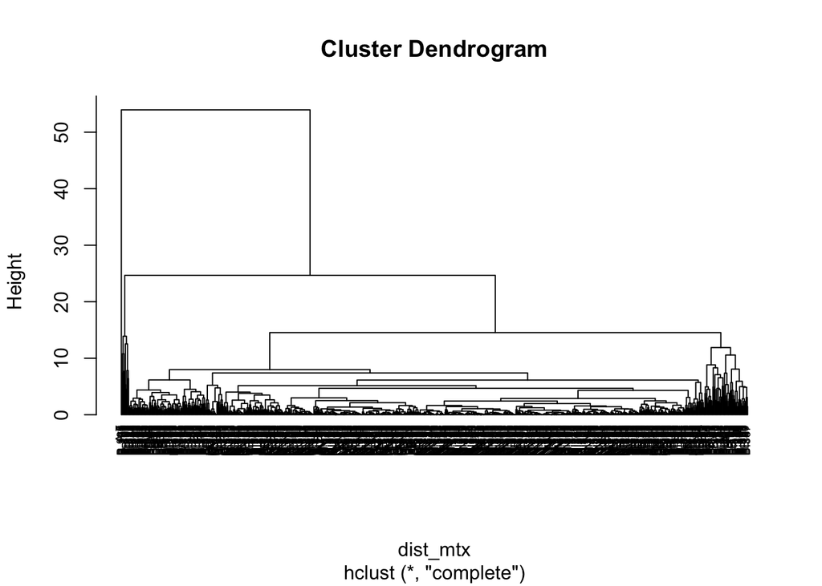

```r
# Dissimilarity matrix
dist_mtx <- dist(DotaData_NoSkill, method = "euclidean")

# Hierarchical clustering using Complete Linkage
hc1 <- hclust(dist_mtx, method = "complete" )

# Plot the obtained dendrogram.
plot(hc1, cex = 0.6, hang = -1)
```

Some notes:

- `hclust` takes as input a distance matrix, so while we are using Euclidean distance here, you can try with other metrics, but will keep that as an exercise.
- we are running `hclust` with complete-linkage here. Other options include `single`, `average`, `ward.D2`, etc.
- The last command in the above code plots the obtained dendrogram. Due to the large size of our data set, the plot is a bit hard to see.

Later, we can discuss how to evaluate the clustering result.

2. HC implementations from `cluster`

Alternatively, we can also use the function `agnes` from the `cluster` library for agglomerative HC.

```r
# Compute with agnes
hc2 <- agnes(DotaData_NoSkill, method = "complete")
```

The output returned from `agnes` contains the agglomerative coefficient (AC), which represents the cluster tendency in the data. AC takes value between 0 and 1, with higher value indicating higher cluster tendency

```r
hc2$ac
```

```
## [1] 0.9867219
```

Given ACs, we can then compare different `agnes` methods, such as “average”, “single”, “complete”, and “ward”.

```r
##### assess different methods with agnes (average/complete/single/ward)
# methods to assess
m <- c( "average", "single", "complete", "ward")
names(m) <- c( "average", "single", "complete", "ward")

# function to compute coefficient
ac <- function(x) {
  agnes(DotaData_NoSkill, method = x)$ac
}

map_dbl(m, ac)
```

```
##   average    single  complete      ward
## 0.9864255 0.9809992 0.9867219 0.9932920
```

`map_dbl` is a utility function from `tidyverse` that simplifies “while”-loop. Here, we use it to compute ACs of all the aforementioned methods. It seems that “ward” is the best method here.

Next, let’s visualize the dendrogram of the best method “ward”, using `pltree`. Note that `pltree` only works with outputs of `agnes` and `diana`, and not `hclust` from the `stats` package.

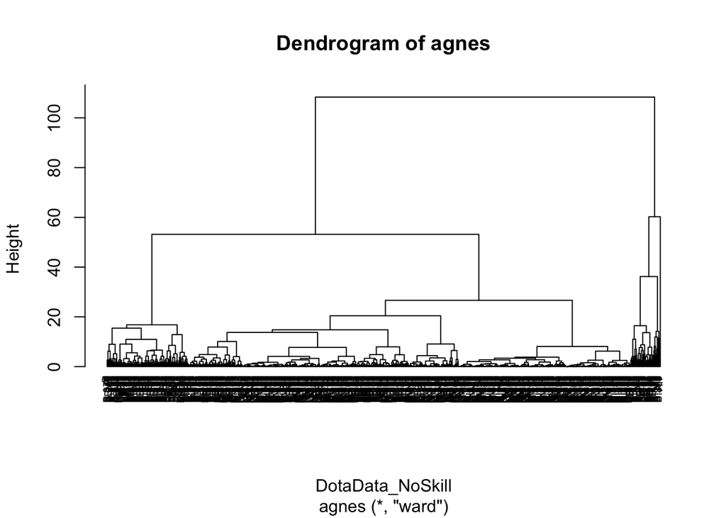

```r
##### visualize the dendrogram of ward method
hc3 <- agnes(DotaData_NoSkill, method = "ward")
pltree(hc3, cex = 0.6, hang = -1, main = "Dendrogram of agnes")
```

Similarly, we can apply the above steps with `diana`, the divisive HC method.

```r
# compute divisive hierarchical clustering
hc4 <- diana(DotaData_NoSkill)

# Divise coefficient; amount of clustering structure found
hc4$dc
```

[output not shown]

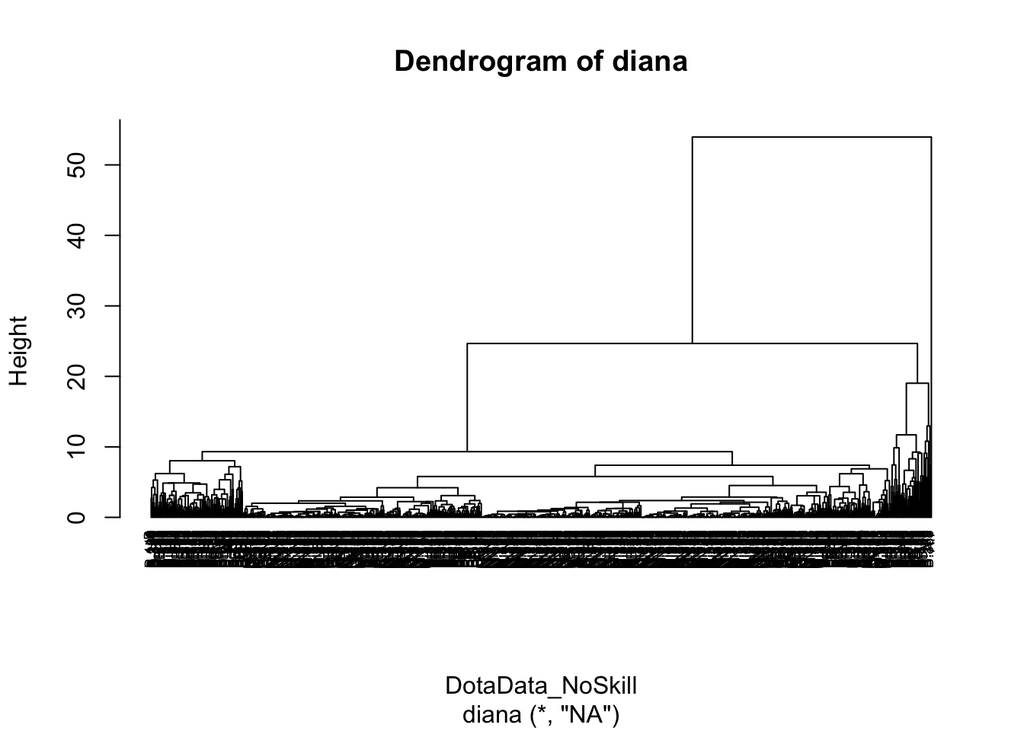

```r
## [1] 0.9825621

# plot dendrogram
pltree(hc4, cex = 0.6, hang = -1, main = "Dendrogram of diana")
```

Note that `diana` does not allow the setting of any merging method, e.g. “complete”, “single”, or “average”.

# Step 3: Cut the tree to obtain clustering

After running HC algorithms, we obtain a dendrogram representing the hierarchy of data partitions. Next, we will cut the tree to obtain concrete clusterings. This way we can make sense of the data, as you can see from all the outputs of the different HC methods above, there are many clusters from the data point. So we need to inspect at the right level by cutting the tree at the optimal cluster level.

1. Obtaining the optimal cut point

Before cutting the tree, we need to determine which cutting is most optimal. Here, we will apply the Elbow method again, by examining the WSS (Within-cluster Sum of Squares) plot with respect to varying numbers of clusters K.

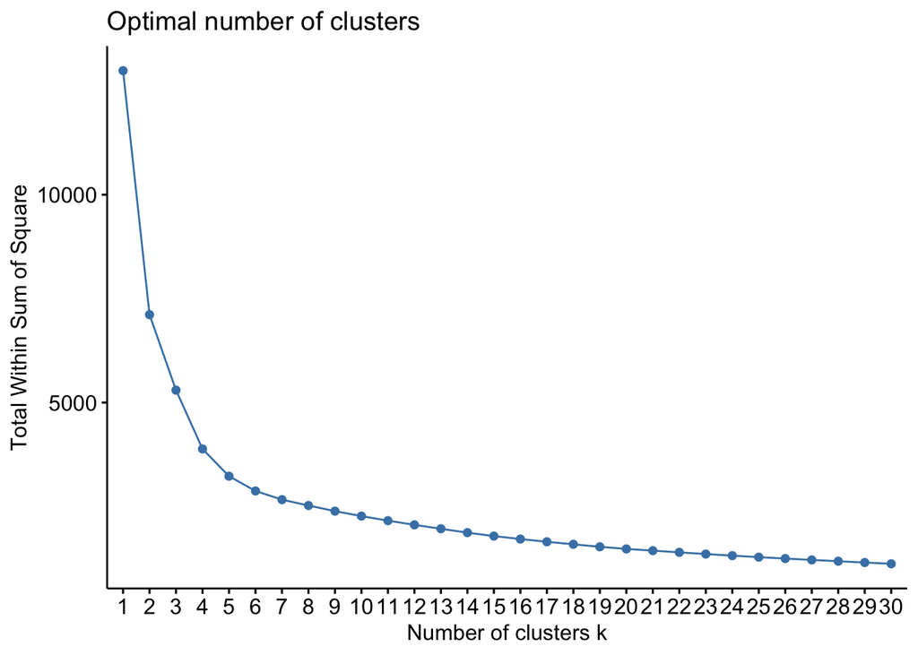

```r
# plot using WSS metric
fviz_nbclust(DotaData_NoSkill, FUN = hcut, method = "wss", k.max = 30)
```

```r
# the plot is quite smooth, so it's not easy, but 5 to 8 seems reasonable
```

Following the `Elbow` method, the best K seems to be `5` in this case.

Alternatively, we can draw a similar plot with the y-axis being average silhouette width.

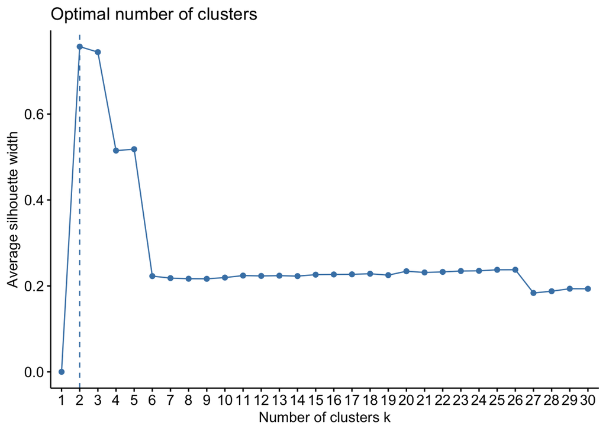

```r
# plot using average silhouette width
fviz_nbclust(DotaData_NoSkill, FUN = hcut, method = "silhouette", k.max = 30)
```

Unlike the previous plot, in this plot, the goal is to select K with the highest average width. `K=2` is the highest, 3 is the 2nd highest, but `5` is interestingly better than `4`.

The consensus here points to `K=5` as a reasonably optimal choice.

2. Cut the `hclust` tree

Let’s try with the dendrogram from `hclust` first, with number of clusters `K` set to 5.

```r
# Ward's method in hclust : dist_mtx is the distance matrix
hc5 <- hclust(dist_mtx, method = "ward.D2" )

# Cut tree into K groups
num_clus <- 5
sub_grp <- cutree(hc5, k = num_clus)

# Number of members in each cluster
table(sub_grp)
```

```
## sub_grp
##   1   2   3   4   5
## 128 691  36  10   1
```

To identify what data point belongs to which cluster we can inspect `sub_grp` variable.

```r
sub_grp
```

```
##     B   B.1     N   B.2   N.1   N.2   B.3   B.4   N.3   N.4   B.5   B.6   B.7
##     1     2     2     1     2     2     2     2     2     1     1     2     1
##   N.5   B.8   N.6   N.7   B.9     A   N.8  B.10  B.11  B.12  B.13   N.9  B.14
##     2     1     2     2     1     1     2     2     1     2     1     2     2
##  N.10  N.11  N.12  N.13  N.14  B.15  B.16  B.17  N.15  N.16  N.17  B.18  B.19
##     2     2     2     2     2     1     2     2     2     2     2     2     2
##  N.18  B.20  N.19  B.21  B.22  B.23  N.20  B.24  B.25  B.26  N.21  N.22  B.27
##     2     2     2     2     2     2     2     1     2     2     2     2     2
##  N.23  B.28  B.29  B.30  B.31  B.32  N.24     I  B.33  B.34  B.35  N.25  B.36
##     2     2     2     2     3     1     2     1     2     1     2     2     1
##  N.26  B.37  B.38  B.39  B.40  N.27  N.28  N.29  B.41  B.42  N.30  B.43  N.31
##     2     2     2     2     2     2     2     2     2     2     2     1     2
##  B.44  B.45  N.32  B.46  B.47  N.33  N.34   I.1   A.1  N.35  B.48  B.49  B.50
##     2     1     2     2     1     2     2     3     1     2     2     2     1
##  B.51  B.52  N.36  N.37  B.53  N.38  N.39  N.40  B.54  N.41  B.55  B.56  B.57
##     1     1     2     2     1     2     2     2     1     2     2     2     2
##  N.42  B.58  N.43  B.59   A.2  N.44  B.60   I.2  B.61  B.62  N.45  N.46  B.63
##     2     2     2     3     1     2     2     1     2     2     2     2     1
##  B.64  N.47  B.65  B.66  N.48  B.67  B.68  B.69  N.49  N.50  B.70   I.3  B.71
##     1     2     1     2     2     3     2     1     2     2     3     1     2
##  B.72  N.51  N.52  N.53  B.73  B.74  N.54  N.55  N.56  N.57  N.58  B.75  N.59
##     1     2     2     2     2     2     2     2     2     2     2     2     2
##  N.60  B.76  N.61  B.77  N.62  N.63  N.64  N.65  N.66  N.67  N.68  N.69  N.70
##     2     2     2     2     2     2     2     2     2     2     2     2     2
##  N.71  N.72  B.78  B.79  N.73  B.80  N.74  B.81  N.75  B.82   I.4  B.83  N.76
##     2     2     1     3     2     1     2     3     2     2     1     2     2
##  N.77   A.3  B.84  B.85  N.78  B.86  B.87   A.4  B.88  N.79  B.89  N.80  B.90
##     2     1     2     2     2     2     2     1     2     2     1     2     2
##  N.81  N.82  N.83  B.91  B.92  B.93  N.84  N.85  N.86  B.94  B.95  B.96  B.97
##     2     2     2     1     2     3     2     2     2     1     4     3     1
##  B.98  B.99  N.87  N.88 B.100  N.89  N.90  N.91  N.92  N.93  N.94 B.101 B.102
##     1     2     2     2     2     2     2     2     2     2     2     2     2
## B.103  N.95 B.104  N.96 B.105  N.97  N.98  N.99 B.106 B.107 N.100 B.108 B.109
##     2     2     2     2     2     2     2     2     1     4     2     2     2
## N.101 N.102 N.103 N.104 B.110 N.105 B.111 B.112 N.106 B.113 N.107 B.114 N.108
##     2     2     2     2     2     2     1     1     2     2     2     3     2
## B.115 N.109 B.116 B.117 B.118 N.110 B.119 N.111 N.112 B.120 B.121 B.122 B.123
##     1     2     1     3     2     2     2     2     2     2     2     3     2
## N.113 B.124 B.125 B.126 N.114 N.115 N.116 N.117 B.127 B.128 B.129 B.130 N.118
##     2     2     2     2     2     2     2     2     2     2     2     2     2
```

[output cut: 79 more lines]

```
##     2     2     2     1     2     2     2     2     2     2     1     2     2
## N.402 B.352 B.353 N.403 N.404 N.405 N.406 N.407 N.408 N.409 B.354 N.410 B.355
##     2     2     2     2     2     2     2     2     2     2     3     2     2
## N.411 N.412  I.15 N.413 N.414 N.415 B.356 N.416 B.357 B.358 B.359 N.417 N.418
##     2     2     3     2     2     2     1     2     2     2     1     2     2
## N.419 N.420 N.421 N.422 N.423 N.424 B.360 N.425 N.426 N.427 B.361 N.428 N.429
##     2     1     2     2     2     2     2     2     2     2     2     2     2
## B.362 B.363 B.364 N.430 N.431 B.365 B.366 B.367 N.432 B.368 N.433 N.434 B.369
##     1     1     2     2     2     1     2     1     2     1     2     2     2
## N.435 B.370 N.436 B.371 B.372 B.373 N.437 B.374 B.375 B.376  I.16 B.377 N.438
##     2     2     2     4     2     2     2     2     2     2     3     1     2
## N.439 N.440 B.378 B.379 N.441 B.380 N.442 B.381 B.382 B.383 B.384 B.385 B.386
##     2     2     2     1     1     1     2     2     2     2     1     2     2
## B.387 B.388 B.389 N.443 N.444 N.445 B.390 N.446
##     1     2     2     2     2     2     2     2
```

The function `cutree` takes as input the desired number of clusters. The output shows the size of the 5 clusters. It’s interesting to see that there are many small clusters, such as Cluster 4 and 5. It’s very likely that these clusters are noise/outliers in the data.

We can also visualize the clusters by boxing the dendrogram.

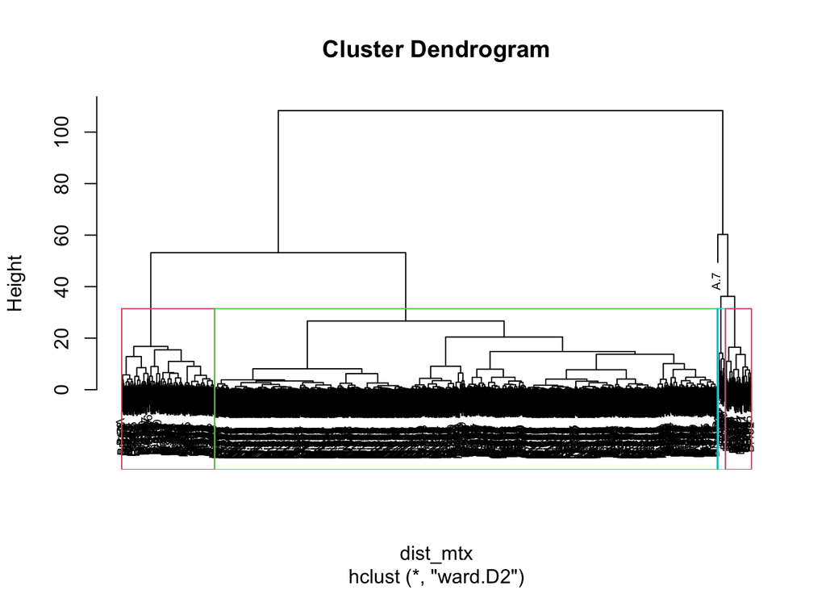

```r
##### draw dendrogram with borders
plot(hc5, cex = 0.6)
rect.hclust(hc5, k = num_clus, border = 2:5)
```

Cluster 2 contains a big part of the data.

You can pull up the help page of `rect.hclust`, by typing `?rect.hclust` in the console, for more information on how to tweak the plot.

# Step 4: Visualization of the Clusters

Alternatively, you can use `fviz_cluster` from the `factoextra` library to visualize the clusters, as you did before.

We here visualize the clusters formed by Hclust.

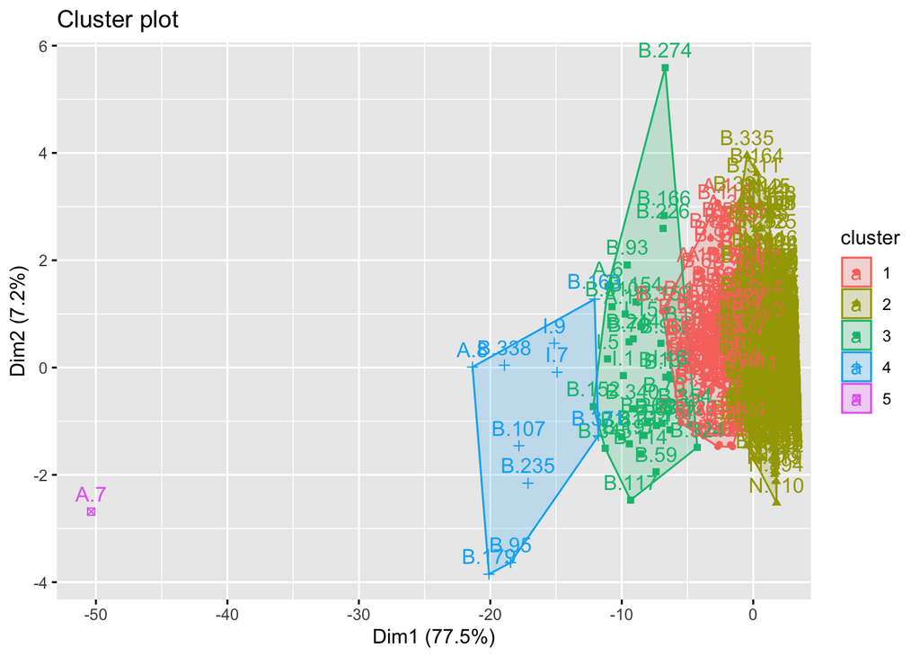

```r
#### visualize the clusters using fviz_cluster for hclust
fviz_cluster(list(data = DotaData_NoSkill, cluster = sub_grp),
             show.clust.cent = FALSE)
```

It is clear that Cluster 5 contains the sole outlier we observed before. This demonstrates a strength of HC: it can detect outliers/noise well.

We can do the same with `agnes` and `diana` trees, by converting them into `hclust` objects.

```r
# Cut agnes() tree
hc_a <- agnes(DotaData_NoSkill, method = "ward")
sub_grp_a <- cutree(as.hclust(hc_a), k = num_clus)
table(sub_grp_a)
```

```
## sub_grp_a
##   1   2   3   4   5
## 128 691  36  10   1
```

Visualize clusters for the Agnes tree.

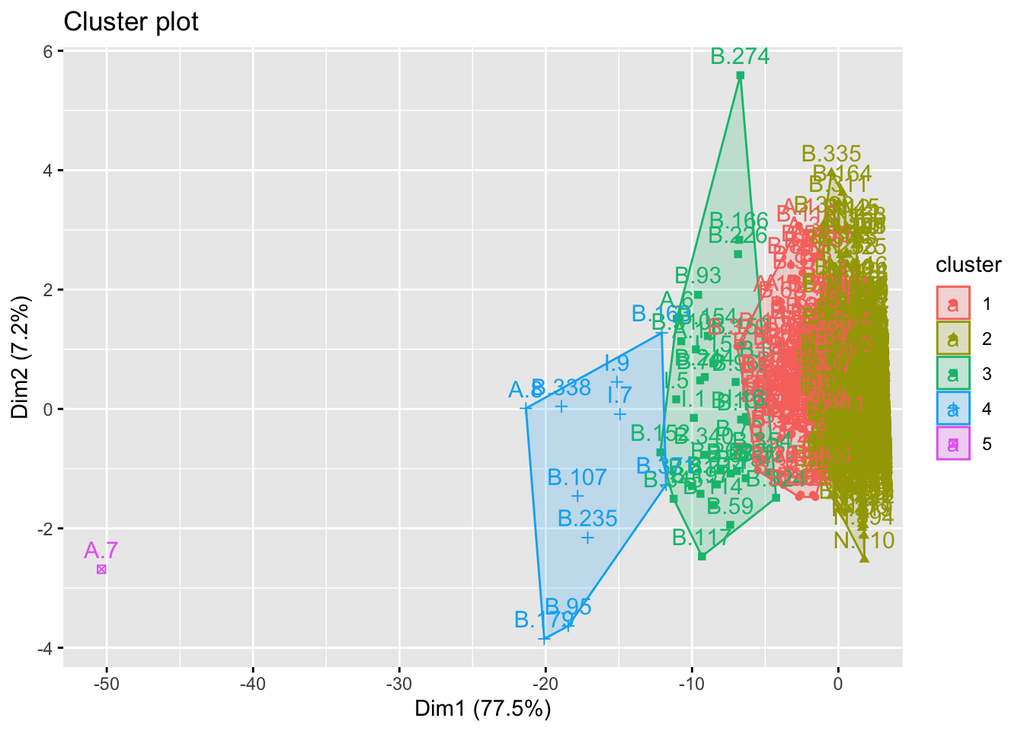

```r
fviz_cluster(list(data = DotaData_NoSkill, cluster = sub_grp_a),
             show.clust.cent = FALSE)
```

We visualize this time with the `diana` function

```r
# Cut diana() tree
hc_d <- diana(DotaData_NoSkill)
sub_grp_d <- cutree(as.hclust(hc_d), k = num_clus)
table(sub_grp_d)
```

```
## sub_grp_d
##   1   2   3   4   5
## 820  37   6   1   2
```

Visualize clusters for the Diana tree.

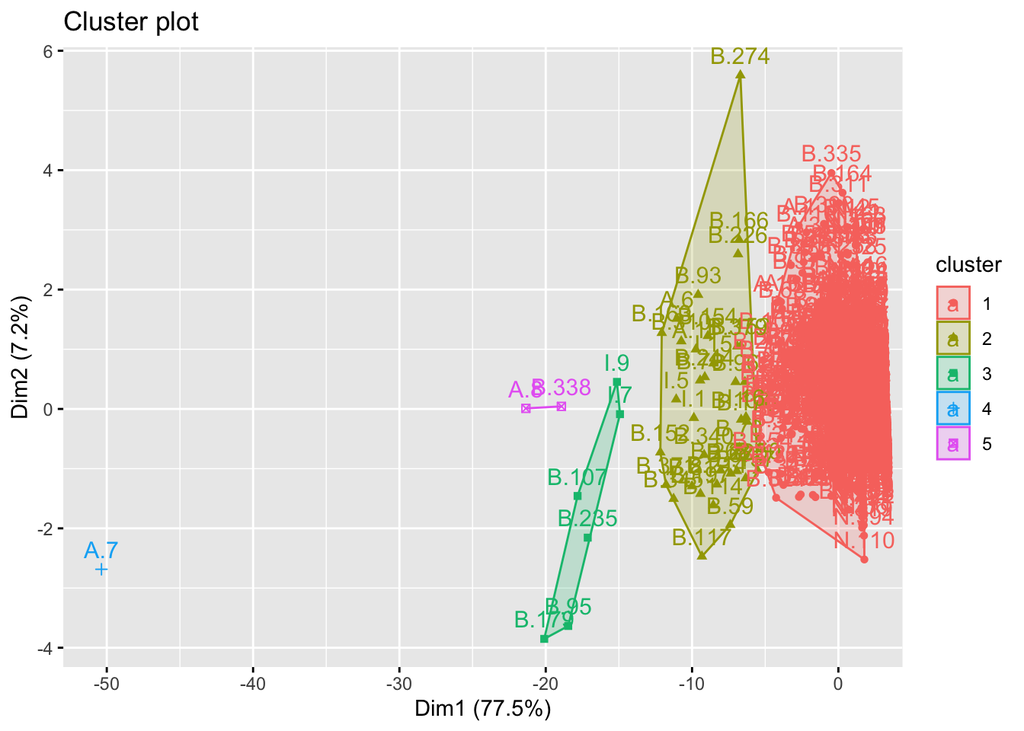

```r
fviz_cluster(list(data = DotaData_NoSkill, cluster = sub_grp_d),
             show.clust.cent = FALSE)
```

Observing the visualization, we can see that while the clusterings by `hclust` and `agnes` are the same, those of `diana` are different: the biggest cluster is now bigger, and the rest are smaller. This is the effect of `diana` emphasizing more on big clusters. It is important to note that as discussed above `hclust` and `agnes` are both agglomerative hierarchical clustering methods while `diana` is a divisive hierarchical clustering method.

# Conclusion

In this lab, we showed you how to use Hierarchical Clustering for cluster analysis. We acknowledge the visualization issues with visualizing the dendogram of the clusters due to the density of the data points used. You may want to repeat with a subset of the data to see how clustering actually works. Or you can use the membership to the clusters to look through your data to see if the clusters make qualitative sense. We usually use a mix of quantiative and qualitative analysis with clustering to make sense of the results.